# Multinatinal Bank Customer Churn

# Chapter 6: Comparing the Models Chosen in Feature Selection

### Methods of Model Evaluation

When evaluating the models, we are **focusing particularly on False negatives** because it is vital for any bank to correctly predict churn and in an ideal scenario without any errors. False negatives are of highest importance as we do not want to incorrectly predict that the customers are retained, when they are in fact churned.

The second way we will be evaluating the models is by Area Under the Curve. The higher this number is, the better our model.

Model with all variables:

```
##
## Call:
## glm(formula = churn ~ ., family = "binomial", data = churn_data_logit)
##
## Deviance Residuals:
##    Min      1Q  Median      3Q     Max
## -2.733  -0.951  -0.646   1.083   2.251
##
## Coefficients:
##                   Estimate Std. Error z value Pr(>|z|)
## (Intercept)      -3.32e+00   2.01e-01  -16.55  < 2e-16 ***
## credit_score     -3.40e-04   2.23e-04   -1.52  0.12811
## country          -1.99e-02   2.63e-02   -0.76  0.44999
## gender           -3.87e-02   4.37e-02   -0.89  0.37595
## age               7.62e-02   2.37e-03   32.08  < 2e-16 ***
## tenure           -4.56e-03   7.49e-03   -0.61  0.54265
## balance           4.67e-06   3.65e-07   12.81  < 2e-16 ***
## products_number  -1.15e-01   3.33e-02   -3.45  0.00056 ***
## credit_card      -5.20e-02   4.77e-02   -1.09  0.27510
## active_member     5.22e-02   4.35e-02    1.20  0.23025
## estimated_salary  4.99e-07   3.78e-07    1.32  0.18701
## ---
## Signif. codes:  0 '***' 0.001 '**' 0.01 '*' 0.05 '.' 0.1 ' ' 1
##
## (Dispersion parameter for binomial family taken to be 1)
##
##     Null deviance: 13708  on 9999  degrees of freedom
## Residual deviance: 12226  on 9989  degrees of freedom
## AIC: 12248
##
## Number of Fisher Scoring iterations: 4
```

**Model 1 - churn ~ age + balance**

```
##
## Call:
## glm(formula = churn ~ age + balance, data = churn_data_logit)
##
## Deviance Residuals:
##    Min      1Q  Median      3Q     Max
## -1.332  -0.377  -0.182   0.456   1.015
##
## Coefficients:
##              Estimate Std. Error t value Pr(>|t|)
## (Intercept) -3.10e-01   1.94e-02   -16.0   <2e-16 ***
## age          1.64e-02   4.47e-04    36.7   <2e-16 ***
## balance      1.04e-06   7.52e-08    13.9   <2e-16 ***
## ---
## Signif. codes:  0 '***' 0.001 '**' 0.01 '*' 0.05 '.' 0.1 ' ' 1
##
## (Dispersion parameter for gaussian family taken to be 0.212)
##
##     Null deviance: 2461.3  on 9999  degrees of freedom
## Residual deviance: 2123.8  on 9997  degrees of freedom
## AIC: 12893
##
## Number of Fisher Scoring iterations: 2
```

Confusion matrix from Logit Model-1

|  | Predicted 0 | Predicted 1 | Total |
| --- | --- | --- | --- |
| Actual 0 | 4590 | 1032 | 5622 |
| Actual 1 | 2059 | 2319 | 4378 |
| Total | 6649 | 3351 | 10000 |

```
## Area under the curve: 0.741
```

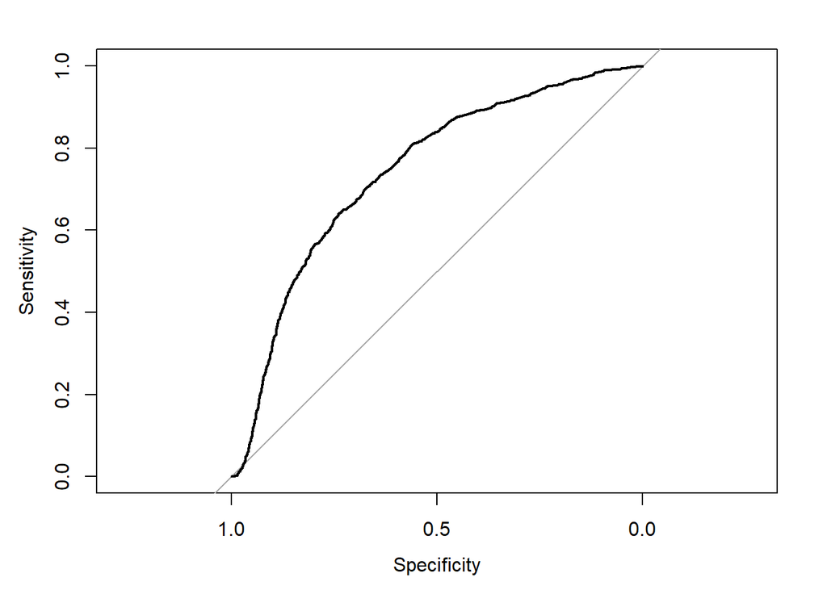

**Model 2 - churn ~ credit_card+age + balance**

```
##
## Call:
## glm(formula = churn ~ credit_card + age + balance, data = churn_data_logit)
##
## Deviance Residuals:
##    Min      1Q  Median      3Q     Max
## -1.329  -0.376  -0.180   0.457   1.018
##
## Coefficients:
##              Estimate Std. Error t value Pr(>|t|)
## (Intercept) -3.02e-01   2.06e-02  -14.65   <2e-16 ***
## credit_card -1.18e-02   1.01e-02   -1.17     0.24
## age          1.64e-02   4.47e-04   36.74   <2e-16 ***
## balance      1.04e-06   7.52e-08   13.88   <2e-16 ***
## ---
## Signif. codes:  0 '***' 0.001 '**' 0.01 '*' 0.05 '.' 0.1 ' ' 1
##
## (Dispersion parameter for gaussian family taken to be 0.212)
##
##     Null deviance: 2461.3  on 9999  degrees of freedom
## Residual deviance: 2123.5  on 9996  degrees of freedom
## AIC: 12894
##
## Number of Fisher Scoring iterations: 2
```

Confusion matrix from Logit Model-2

|  | Predicted 0 | Predicted 1 | Total |
| --- | --- | --- | --- |
| Actual 0 | 4586 | 1036 | 5622 |
| Actual 1 | 2068 | 2310 | 4378 |
| Total | 6654 | 3346 | 10000 |

```
## Area under the curve: 0.741
```

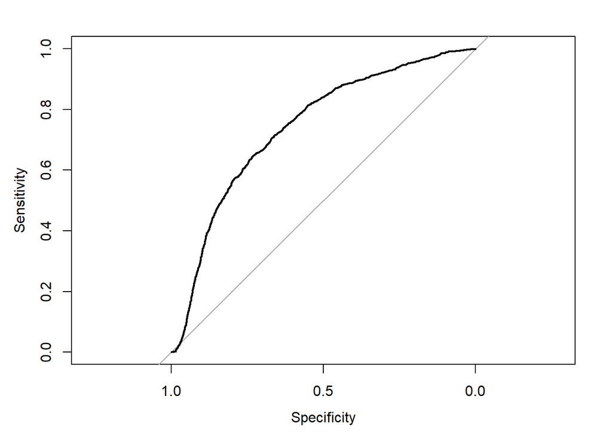

**Model 3 - churn ~ credit_score+age+tenure+ balance + active_member+estimated_salary**

```
##
## Call:
## glm(formula = churn ~ credit_score + age + tenure + balance +
##     active_member + estimated_salary, data = churn_data_logit)
##
## Deviance Residuals:
##    Min      1Q  Median      3Q     Max
## -1.317  -0.375  -0.183   0.456   1.029
##
## Coefficients:
##                   Estimate Std. Error t value Pr(>|t|)
## (Intercept)      -2.69e-01   3.89e-02   -6.91    5e-12 ***
## credit_score     -8.05e-05   4.73e-05   -1.70    0.089 .
## age               1.64e-02   4.47e-04   36.65   <2e-16 ***
## tenure           -8.89e-04   1.59e-03   -0.56    0.576
## balance           1.05e-06   7.52e-08   13.94   <2e-16 ***
## active_member     1.21e-02   9.22e-03    1.31    0.190
## estimated_salary  1.01e-07   8.01e-08    1.25    0.210
## ---
## Signif. codes:  0 '***' 0.001 '**' 0.01 '*' 0.05 '.' 0.1 ' ' 1
##
## (Dispersion parameter for gaussian family taken to be 0.212)
##
##     Null deviance: 2461.3  on 9999  degrees of freedom
## Residual deviance: 2122.4  on 9993  degrees of freedom
## AIC: 12894
##
## Number of Fisher Scoring iterations: 2
```

Confusion matrix from Logit Model-3

|  | Predicted 0 | Predicted 1 | Total |
| --- | --- | --- | --- |
| Actual 0 | 4572 | 1050 | 5622 |
| Actual 1 | 2045 | 2333 | 4378 |
| Total | 6617 | 3383 | 10000 |

```
## Area under the curve: 0.741
```

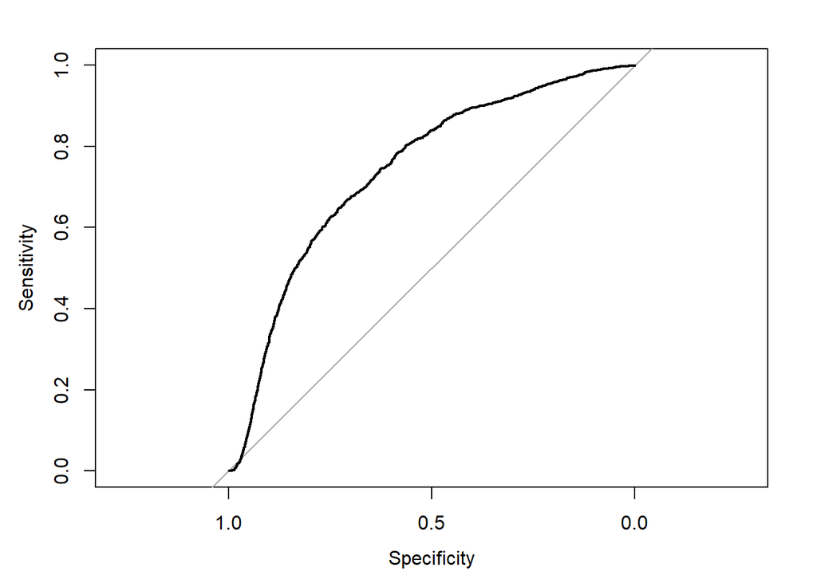

**Model 4 - churn ~ credit_score + country+ gender+age+tenure+balance+active_member+credit_card+estimated_salary**

```
##
## Call:
## glm(formula = churn ~ credit_score + country + gender + age +
##     tenure + balance + active_member + credit_card + estimated_salary,
##     data = churn_data_logit)
##
## Deviance Residuals:
##    Min      1Q  Median      3Q     Max
## -1.309  -0.376  -0.183   0.457   1.022
##
## Coefficients:
##                   Estimate Std. Error t value Pr(>|t|)
## (Intercept)      -2.54e-01   4.00e-02   -6.36  2.2e-10 ***
## credit_score     -8.03e-05   4.73e-05   -1.70     0.09 .
## country          -4.18e-03   5.57e-03   -0.75     0.45
## gender           -7.43e-03   9.26e-03   -0.80     0.42
## age               1.64e-02   4.47e-04   36.64  < 2e-16 ***
## tenure           -9.11e-04   1.59e-03   -0.57     0.57
## balance           1.05e-06   7.52e-08   13.92  < 2e-16 ***
## active_member     1.19e-02   9.23e-03    1.28     0.20
## credit_card      -1.20e-02   1.01e-02   -1.18     0.24
## estimated_salary  1.03e-07   8.02e-08    1.29     0.20
## ---
## Signif. codes:  0 '***' 0.001 '**' 0.01 '*' 0.05 '.' 0.1 ' ' 1
##
## (Dispersion parameter for gaussian family taken to be 0.212)
##
##     Null deviance: 2461.3  on 9999  degrees of freedom
## Residual deviance: 2121.8  on 9990  degrees of freedom
## AIC: 12898
##
## Number of Fisher Scoring iterations: 2
```

Confusion matrix from Logit Model-4

|  | Predicted 0 | Predicted 1 | Total |
| --- | --- | --- | --- |
| Actual 0 | 4589 | 1033 | 5622 |
| Actual 1 | 2053 | 2325 | 4378 |
| Total | 6642 | 3358 | 10000 |

```
## Area under the curve: 0.741
```

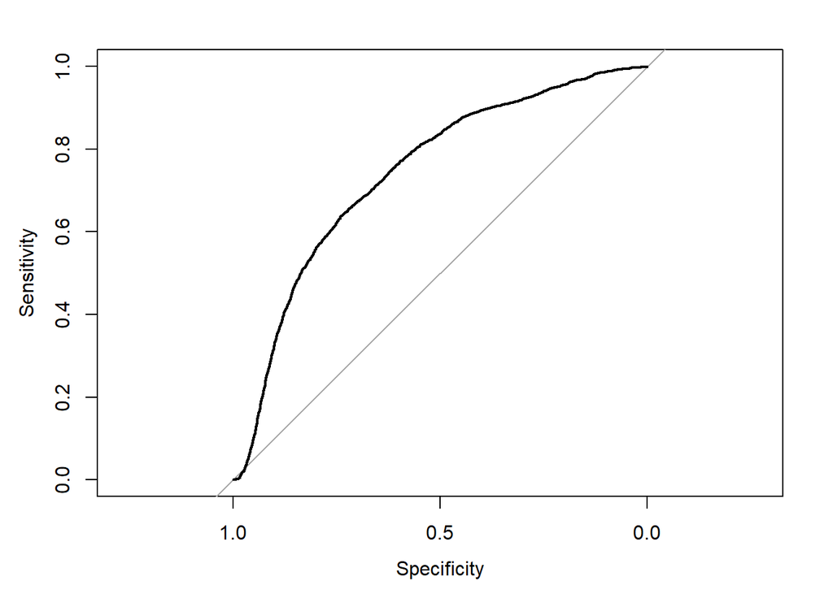

**Model 5 - churn ~ credit_score + country+ gender+age+tenure+balance+active_member+estimated_salary**

```
##
## Call:
## glm(formula = churn ~ credit_score + country + gender + age +
##     tenure + balance + active_member + estimated_salary, data = churn_data_logit)
##
## Deviance Residuals:
##    Min      1Q  Median      3Q     Max
## -1.312  -0.376  -0.184   0.457   1.029
##
## Coefficients:
##                   Estimate Std. Error t value Pr(>|t|)
## (Intercept)      -2.62e-01   3.94e-02   -6.65    3e-11 ***
## credit_score     -8.06e-05   4.73e-05   -1.70    0.088 .
## country          -4.13e-03   5.57e-03   -0.74    0.459
## gender           -7.36e-03   9.26e-03   -0.80    0.426
## age               1.64e-02   4.47e-04   36.63   <2e-16 ***
## tenure           -9.04e-04   1.59e-03   -0.57    0.569
## balance           1.05e-06   7.52e-08   13.94   <2e-16 ***
## active_member     1.20e-02   9.23e-03    1.30    0.194
## estimated_salary  1.01e-07   8.01e-08    1.26    0.207
## ---
## Signif. codes:  0 '***' 0.001 '**' 0.01 '*' 0.05 '.' 0.1 ' ' 1
##
## (Dispersion parameter for gaussian family taken to be 0.212)
##
##     Null deviance: 2461.3  on 9999  degrees of freedom
## Residual deviance: 2122.1  on 9991  degrees of freedom
## AIC: 12897
##
## Number of Fisher Scoring iterations: 2
```

Confusion matrix from Logit Model-5

|  | Predicted 0 | Predicted 1 | Total |
| --- | --- | --- | --- |
| Actual 0 | 4578 | 1044 | 5622 |
| Actual 1 | 2053 | 2325 | 4378 |
| Total | 6631 | 3369 | 10000 |

```
## Area under the curve: 0.741
```

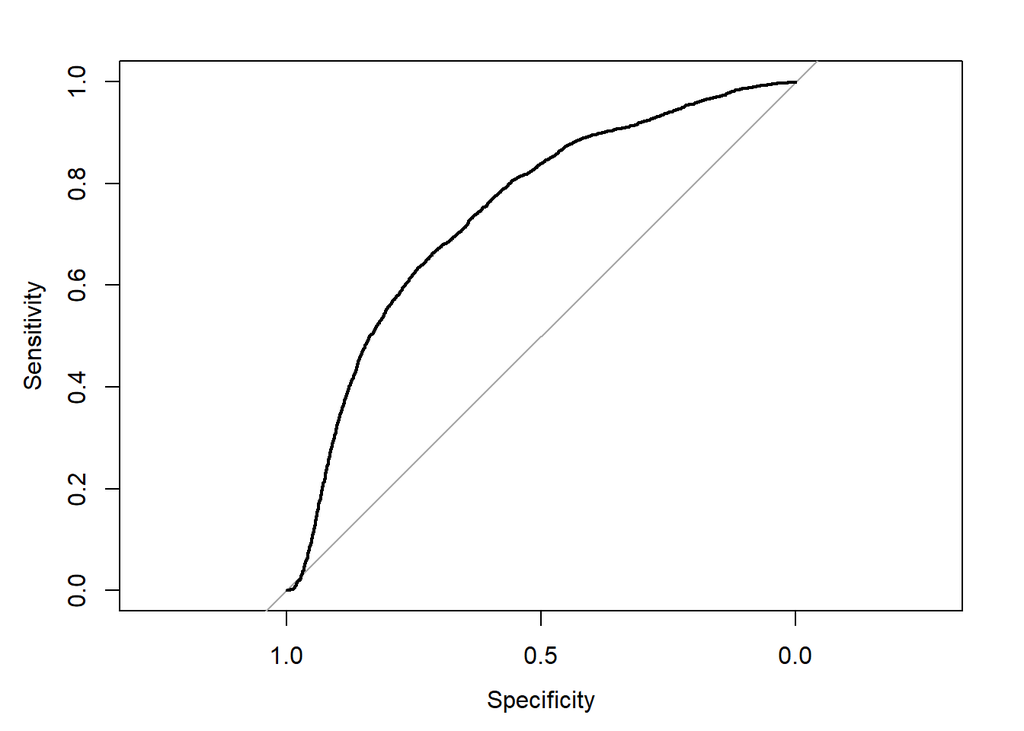

**Model 6 - churn ~ credit_score+country+gender+age+tenure+balance+estimated_salary**

```
##
## Call:
## glm(formula = churn ~ credit_score + country + gender + age +
##     tenure + balance + estimated_salary, data = churn_data_logit)
##
## Deviance Residuals:
##    Min      1Q  Median      3Q     Max
## -1.318  -0.376  -0.184   0.456   1.025
##
## Coefficients:
##                   Estimate Std. Error t value Pr(>|t|)
## (Intercept)      -2.56e-01   3.91e-02   -6.55  6.2e-11 ***
## credit_score     -8.07e-05   4.73e-05   -1.71    0.088 .
## country          -4.08e-03   5.57e-03   -0.73    0.464
## gender           -7.63e-03   9.26e-03   -0.82    0.410
## age               1.64e-02   4.47e-04   36.65  < 2e-16 ***
## tenure           -8.55e-04   1.59e-03   -0.54    0.590
## balance           1.05e-06   7.52e-08   13.93  < 2e-16 ***
## estimated_salary  1.00e-07   8.01e-08    1.25    0.211
## ---
## Signif. codes:  0 '***' 0.001 '**' 0.01 '*' 0.05 '.' 0.1 ' ' 1
##
## (Dispersion parameter for gaussian family taken to be 0.212)
##
##     Null deviance: 2461.3  on 9999  degrees of freedom
## Residual deviance: 2122.5  on 9992  degrees of freedom
## AIC: 12897
##
## Number of Fisher Scoring iterations: 2
```